# Time in range worksheet

A brief, self-contained example of time in range and bootstrapping by patient ID. This example does not yet contain a relative risk calculation.

The example generates its own fake data for completeness. You may instead load CSV data and use that instead in the `range_plot` and `target_range` functions below.

## Fake data

Generate fake data for 100 patients as a data frame with columns: `patient_id, date, hct`. The fake data is stored in the variable `hct_data` below.

Alternatively, load your data from a CSV file.

```r
set.seed(1)
# a function that makes up fake data for one patient
patient <- function(...) {
  eval_dates <- sort(sample(60, sample(2:10,1)) + as.Date("2020-1-1"))
  patient_id <- paste(sample(10), collapse="")
  hct <- 30.5 + rnorm(length(eval_dates), sd=3)
  data.frame(patient_id = patient_id, date = eval_dates, hct = hct)
}

hct_data <- Reduce(rbind, Map(patient, seq(100)))
```

The fake data looks like:

```r
head(hct_data)
```

```
##    patient_id       date      hct
## 1 51026783149 2020-01-02 27.05703
## 2 51026783149 2020-01-05 29.63162
## 3 51026783149 2020-01-15 29.60235
## 4 51026783149 2020-01-19 29.26547
## 5 51026783149 2020-01-24 31.25667
## 6 51026783149 2020-02-03 27.82424
```

## Plot one patient’s data

```r
range_plot <- function(id, data, id_field, low, high, interp_limit, carry_forward) {
  i <- data[[id_field]] == id
  dates <- data[["date"]][i]
  vals <- data[["hct"]][i]
  ylim <- range(c(vals, low * 0.85, high * 1.15))
  plot.new()
  plot.window(xlim = range(c(dates, max(dates) + carry_forward)), ylim = ylim)
  points(dates, vals, pch="x", cex=1.5)
  dt <- c(0, as.integer(diff(dates)))
  # add linear interpolants
  j <- which(dt < interp_limit)[-1]
  for(k in j) lines(x=c(dates[k-1], dates[k]), y=c(vals[k-1], vals[k]), col=4, lwd=3)
  # add carry forward
  j <- c(which(dt >= interp_limit) - 1, length(dates))
  for(k in j) lines(x=c(dates[k], dates[k] + carry_forward), y=c(vals[k], vals[k]), col=7, lwd=3)
  abline(h=low, lwd=2, lty=2)
  abline(h=high, lwd=2, lty=2)
  axis(1, labels = as.character(dates), at = dates)
  axis(2)
  box()
  title(xlab = "Date")
  title(ylab = "Hct")
  title(main = paste("ID", id))
}
```

Here is an example using the fake `hct_data`:

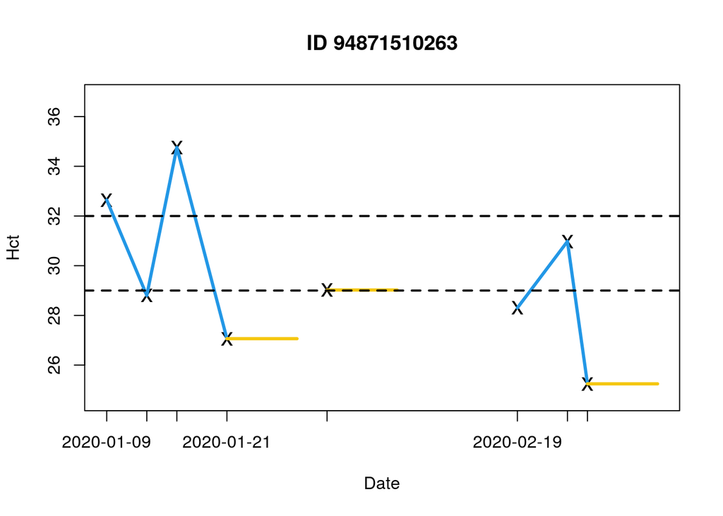

```r
range_plot("94871510263", hct_data, "patient_id", low=29, high=32, interp_limit=7, carry_forward=7)
```

## Time in Range computation

The following rather complicated function records the time spent above, within, and below the target range for a given single patient ID, subject to the specified interpolation and carry forward values. It returns a data frame with (patient) id, time, and range values.

The function arguments are identical to the plot function above:

This function is a bit complicated and can probably be simplified. There is nothing advanced within, it’s all very simple. Just a bit long…

```r
target_range = function(id, data, id_field, low, high, interp_limit, carry_forward) {
  if(carry_forward < interp_limit) stop("carry_forward must be >= interp_limit")
  i <- data[[id_field]] == id
  dates <- data[["date"]][i]
  vals <- data[["hct"]][i]
  k <- order(dates)
  dates <- dates[k]
  vals <- vals[k]
  # add linear interpolant points outside of target range
  dt <- c(0, as.numeric(diff(dates)))
  j <- which(dt < interp_limit)[-1]
  j <- j[(vals[j-1]  < low & low <= vals[j]) | (high < vals[j-1] & vals[j] <= high)]
  if(length(j) > 0) {
    m <- (vals[j] - vals[j-1]) / dt[j]
    y <- low * (vals[j-1] < low) + high * (high < vals[j-1])
    x <- (y - vals[j]) / m + dates[j]
    dates <- c(dates, x)
    vals <- c(vals, y)
    k <- order(dates)
    dates <- dates[k]
    vals <- vals[k]
  }
  # Add remaining interpolated crossings (if any)...
  dt <- c(0, as.numeric(diff(dates)))
  j <- which(dt < interp_limit)[-1]
  j <- j[(low <= vals[j-1] & vals[j-1] <= high & vals[j] < low) | (low <= vals[j-1] & vals[j-1] <= high & high < vals[j])]
  if(length(j) > 0) {
    m <- (vals[j] - vals[j-1]) / dt[j]
    y <- low * (vals[j] < low) + high * (high < vals[j])
    x <- (y - vals[j]) / m + dates[j]
    dates <- c(dates, x)
    vals <- c(vals, y)
    k <- order(dates)
    dates <- dates[k]
    vals <- vals[k]
  }

  # Add up times below, target, and above target range
  dt <- c(0, as.numeric(diff(dates)))
  j <- which(dt < interp_limit)[-1]
  r <- c("above", "target", "below")[
             1 * (vals[j] > high | vals[j-1] > high) +
             2 * (low <= vals[j] & vals[j] <= high & low <= vals[j-1] & vals[j-1] <= high) +
             3 *(vals[j-1] < low | vals[j] < low) ]

  ans <- if(length(j) > 0) {
           data.frame(id = id, days = dt[j], range = r)
         } else {
           data.frame()
         }

  # Add in piecewise-constant interpolated times (carry-forward times)
  # and missing time
  j <- unique(c(which(dt >= interp_limit)-1, length(dates)))
  y <- c("above", "target", "below") [
             1 * (vals[j] > high) +
             2 * (low <= vals[j] & vals[j] <= high) +
             3 *(vals[j] < low) ]
  total_missing <- as.numeric(max(dates) + carry_forward - min(dates)) - sum(ans[["days"]]) - carry_forward * length(y)
  rbind(ans, data.frame(id = id, days = carry_forward, range = y), data.frame(id = id, days = total_missing, range = "missing"))
}
```

Here is an example time in range computation using the fake `hct_data` data for one patient ID:

```r
target_range("94871510263", hct_data, "patient_id", low=29, high=32, interp_limit=7, carry_forward=7)
```

```
##             id        days   range
## 1  94871510263  0.67090464   above
## 2  94871510263  3.12546061  target
## 3  94871510263  0.20363475   below
## 4  94871510263  0.09855976   below
## 5  94871510263  1.51273128  target
## 6  94871510263  1.38870895   above
## 7  94871510263  1.79035934   above
## 8  94871510263  1.95025212  target
## 9  94871510263  1.25938853   below
## 10 94871510263  1.30593052   below
## 11 94871510263  3.69406948  target
## 12 94871510263  0.69014179  target
## 13 94871510263  1.30985821   below
## 14 94871510263  7.00000000   below
## 15 94871510263  7.00000000  target
## 16 94871510263  7.00000000   below
## 17 94871510263 15.00000000 missing
```

## Compite time in range for all patient IDs

Simply Map the `target_range` function across all the data, again using the fake `hct_data` above. We combine the data frame result for each patient using `rbind` and `Reduce` into a single data frame:

```r
ranges <- Reduce(rbind,
            Map(function(i) target_range(i, hct_data, "patient_id", low=29, high=32, interp_limit=7, carry_forward=7),
                unique(hct_data[["patient_id"]])))
```

Now, aggregate all time in each range for all data:

```r
tir <- aggregate(list(total_time = ranges[["days"]]), by=list(range=ranges[["range"]]), FUN=sum)
tir[["percent"]] = tir$total_time / sum(ranges[["days"]])

tir
```

```
##     range total_time   percent
## 1   above   945.5975 0.1935717
## 2   below  1020.3111 0.2088661
## 3 missing  1671.0000 0.3420676
## 4  target  1248.0913 0.2554946
```

## Bootstrap across patient IDs

The above time in range computation shows the breakdown for all patients. We can get a sense of variability in the patient population by bootstrapping across patients. The bootstrap code below samples across blocks of *patient IDs* with replacement.

```r
N <- 1000  # Number of bootstraps
tir_bootstrapped <- Reduce(rbind, replicate(N, {
  i <- ranges[["id"]] %in% sample(unique(ranges[["id"]]), replace = TRUE)
  tir <- aggregate(list(total_time = ranges[["days"]][i]), by=list(range=ranges[["range"]][i]), FUN=sum)
  tir[["percent"]] = tir$total_time / sum(ranges[["days"]][i])
  tir
}, simplify=FALSE))
```

Some statistics on the bootstrapped per cent time within each range are computed below. When the number of bootstraps `N` is large enough, the mean per cent times closely match the total per cent times (shown above in the `tir` variable):

```r
aggregate(list(mean_percent_time = tir_bootstrapped[["percent"]]), by=list(range = tir_bootstrapped[["range"]]), FUN=mean)
```

```
##     range mean_percent_time
## 1   above         0.1930790
## 2   below         0.2089438
## 3 missing         0.3426953
## 4  target         0.2552818
```

And the standard deviations…

```r
aggregate(list(sd_percent_time = tir_bootstrapped[["percent"]]), by=list(range = tir_bootstrapped[["range"]]), FUN=sd)
```

```
##     range sd_percent_time
## 1   above      0.01063137
## 2   below      0.01115746
## 3 missing      0.01101874
## 4  target      0.01039862
```

Of course, for standard deviations to make sense we should confirm that the bootstrapped values look approximately Gaussian. The following example plots a smoothed histogram for the bootstrapped values for values in the target range.

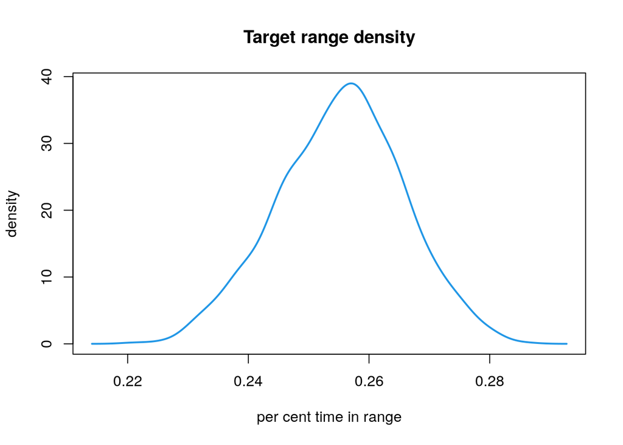

```r
d <- aggregate(list(density = tir_bootstrapped[["percent"]]), by=list(range = tir_bootstrapped[["range"]]), FUN=density)
i <-  which(d[["range"]] == "target")

plot(d[i,"density"][1,]$x, d[i,"density"][1,]$y, type="l", lwd=2, col=4,
     main="Target range density", xlab="per cent time in range", ylab="density")
```

This plot uses fake data, and so it looks pretty good. Deviations from a bell curve here might indicate problematic data, or not enough data.